# act_report

## Act_Report

-The three (3) or more insights the student found are communicated. At least one (1) visualization is included.

-This document (act_report.pdf or act_report.html) is at least 250 words in length.

During my data analyst, wrangling for the Wrangle_Act Project I began to wonder what certain outcomes would be as the three dataframes came together as one. Some insights I hoped to discover along the way would include the following:

1. Which would be the most popular dog breed?
2. Which Dog stage would be most commonly used?
3. Was there going to be an output to support where data was coming from?
4. What would some of the most popular dog names currently being used?
5. How does the retweets vs favorites compare?

Upon finishing my analyst I was very shocked at the outcomes. I will share below each question being answered but will say I was pleasantly shocked at how close the most popular dog breed was over all. As I further my career as a data analyst I find each project challenging but even more rewarding when it comes together in the end. Having to use three different dataframes and cleaning each to make an ultimate master csv file not only included a lot of coffee but enlightening to see how much data surrounds us everyday and what the possibilities could be.

Now I will take you through each question to share each insight I obtained during my analysis process and I hope you too enjoy not only the work but the outcomes to each question. I challenge you before we start to write your guesses down and see what you come up with at the end of this report.

[figure not shown]

## Question 1

1. Which would be the most popular dog breed?

Using the analysis of p1, p2, and p3 columns in the dataframe I will provide the winning popular breed.

## P1 winner golden retriever!

[figure not shown]

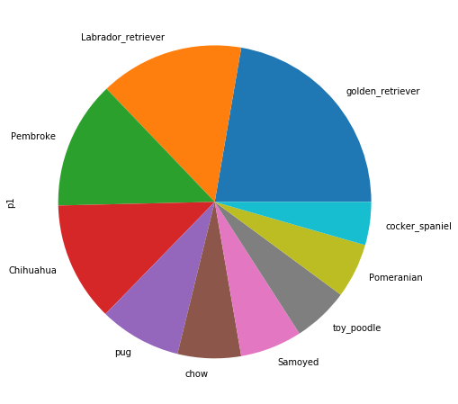

```
Labrador_retriever          104
golden_retriever             92
Cardigan                     73
Chihuahua                    44
Pomeranian                   42
French_bulldog               41
Chesapeake_Bay_retriever     41
toy_poodle                   37
cocker_spaniel               34
Siberian_husky               33
Name: p2, dtype: int64
```

## P2 winner labrador retriever!

[figure not shown]

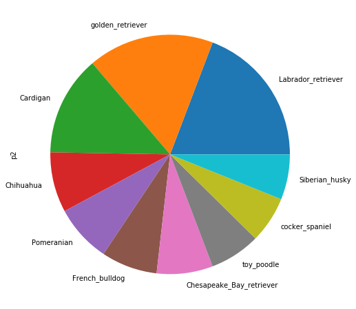

```
Labrador_retriever           79
Chihuahua                    58
golden_retriever             48
Eskimo_dog                   38
kelpie                       35
kuvasz                       34
chow                         32
Staffordshire_bullterrier    32
beagle                       31
cocker_spaniel               31
Name: p3, dtype: int64
```

## P3 winner labrador retriever!

[figure not shown]

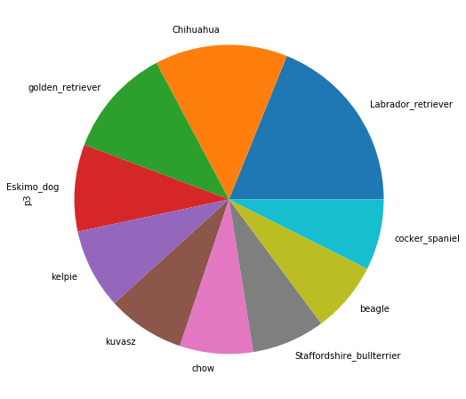

## Taking into consideration each value the Golden wins at 290 vs the Lab at 283!!

[figure not shown]

## Question 2

1. Which Dog stage would be most commonly used?

```
pupper     265
doggo       93
puppo       37
floofer      4
Name: dog_stage, dtype: int64
```

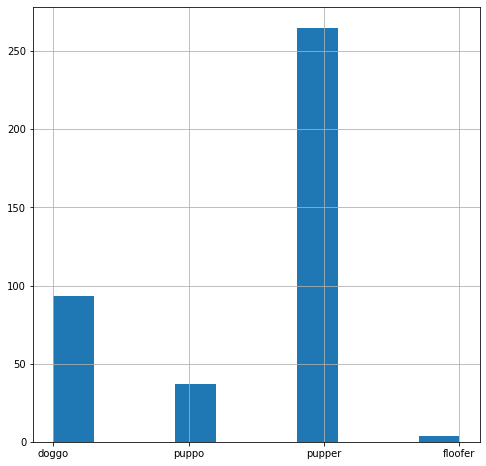

## Outcome for the most used dog stage was pupper!

## Question 3

1. Was there going to be an output to support where data was coming from?

```
Twitter for iPhone     2221
Vine - Make a Scene      91
Twitter Web Client       33
TweetDeck                11
Name: source, dtype: int64
```

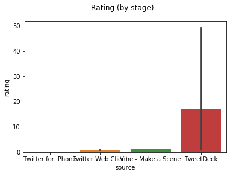

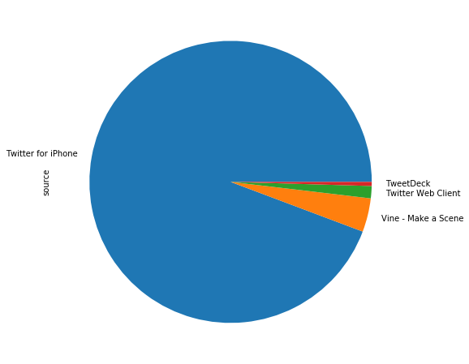

## Question 4

1. What would some of the most popular dog names currently being used?

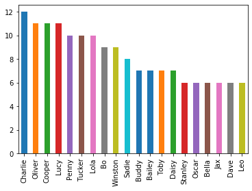

## Here are the top 20 names popular amongst the data collected.

## Top five

1. Charlie
2. Oliver
3. Copper
4. Lucy
5. Penny

## Question 5

1. How does the retweets vs favorites compare?

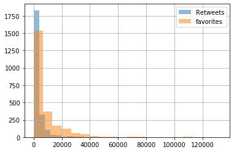